# Data Viz Assignment

Author

Alana Graham

Published

October 9, 2026

## Story

Worldwide box office revenues were identified through https://www.boxofficemojo.com/year/world/.

Adjustments for inflation were made by referencing cumulative inflation figures from https://www.officialdata.org/us/inflation/.

I then used the Wayback Machine (https://web.archive.org/) to identify the Rotten Tomatoes critic and all-audience scores within the first 90 days of each movie’s initial theatrical release.

I then identified whether movies were sequels or based on existing, well-known intellectual property at the time of theatrical release.

## Version A: Scientific

```r
library(tidyverse)
library(gt)
library(psych)
library(readxl)
library(dplyr)
library(janitor)
library(ggplot2)
library(scales)
library(patchwork)
library(gganimate)
library(gifski)
library(readr)
library(ggiraph)
library(ggExtra)
library(plotly)

Data_Viz_Assignment_Dataset <- read_xlsx("Data Viz Assignment Dataset.xlsx")
Top_Movies <- Data_Viz_Assignment_Dataset |>
  select(Year:Genre) |>
  filter(Year != "NA") |>
  mutate(Year = as.numeric(Year)) |>
   mutate(`90-Day Rotten Tomatoes critic score` = `90-Day Rotten Tomatoes critic score`*100) |>
  mutate(`90-Day Rotten Tomatoes audience score` = `90-Day Rotten Tomatoes audience score`*100)

COVID_Removed_List <- Top_Movies |>
  filter(Year != "2020", Year != "2021")

## Graph 1: Revenue (Y) by Year (X)
  ## Scientific --> Scatter plot
Graph_1_Scientific <- ggplot(data = Top_Movies, aes(x = Year, y = `Inflation-Adjusted Box Office`))+
  geom_jitter(alpha = .4)+
  geom_smooth(method = "lm", color = "black", se = TRUE) +
  theme_minimal()+
  labs(title = str_wrap("Inflation-Adjusted Box Office Revenue for the 5 Highest Grossing Films of 2006-2025"), x = "Year", y = "Inflation-Adjusted Worldwide Box Office (USD)")+
  scale_y_continuous(labels = label_dollar(scale_cut = cut_short_scale()))+
  scale_x_continuous(limits = c(2006, 2025),
                     breaks = seq(2006, 2025, 5)) +
  theme(panel.grid.major = element_blank(),
    panel.grid.minor = element_blank(),
    axis.line = element_line(color = "black", linewidth = 0.5))

year_by_revenue_correlation <- cor.test(Top_Movies$Year, Top_Movies$`Inflation-Adjusted Box Office`, method = "pearson")

COVID_removed_year_by_revenue_correlation <- cor.test(COVID_Removed_List$Year, COVID_Removed_List$`Inflation-Adjusted Box Office`, method = "pearson")

Year_Ratings <- Top_Movies |>
  pivot_longer(cols = c(`90-Day Rotten Tomatoes audience score`, `90-Day Rotten Tomatoes critic score`),
               names_to = "Rating Type",
               values_to = "Rating")

Graph_1_Scientific_Rating <- ggplot(data = Year_Ratings, aes(x = Year, y = Rating, colour = `Rating Type`)) +
  geom_point(na.rm = TRUE) +
  geom_smooth(method = "lm",
              se = FALSE,
              fullrange = TRUE,
              linewidth = 1.2,
              na.rm = TRUE) +
  labs(title = "Rotten Tomatoes Ratings Have Steadily Increased Year-by-Year",
       x = "Year",
       y = "Rotten Tomatoes Rating (%)") +
  scale_y_continuous(limits = c(18, 100),
                     breaks = seq(20, 100, 20)) +
  scale_x_continuous(limits = c(2006, 2025),
                     breaks = seq(2006, 2025, 5)) +
  scale_colour_grey(start = 0.2, end = 0.7) +
  theme_minimal() +
  theme(legend.position = "bottom") +
  theme(text = element_text(colour = "black"),
        panel.grid.major = element_blank(),
        panel.grid.minor = element_blank(),
        axis.line = element_line(color = "black", linewidth = 0.5))+
  annotate("label",
           x = 2015,
           y = 30,
           label = "Critic r = .26
Audience r = .48 ",
           fill = "white",
           colour = "black",
           label.size = 0,
           size = 4,
           hjust = 0)

Graph_1_Accessible <- ggplot(data = Top_Movies, aes(x = Year, y = `Inflation-Adjusted Box Office`))+
  stat_summary(aes(group = 1),
    fun = mean,
    geom = "line",
    colour = "red3",
    linewidth = 1.2) +
  stat_summary(aes(group = 1),
    fun = mean,
    geom = "point",
    colour = "orangered4",
    fill = "orangered3",
    shape = 21,
    size = 3) +
  annotate("segment",
    x = 2016,
    y = 750000000,
    xend = 2019.7,
    yend = 540000000,
    colour = "orangered3",
    linewidth = 0.8,
    arrow = arrow(length = unit(0.15, "inches"))) +
  annotate("label",
    x = 2016,
    y = 750000000,
    label = "COVID-19 pandemic",
    fill = "lemonchiffon2",
    colour = "black",
    label.size = 0,
    size = 4) +
  labs(title = str_wrap("How Much Do the Biggest Movies Really Make?"),
    subtitle = "Average worldwide box office for the five biggest films of 2006-2025, adjusted for inflation",
    x = "Year",
    y = "Average worldwide box office (USD)") +
  scale_y_continuous(labels = label_dollar(scale_cut = cut_short_scale())) +
  scale_x_continuous(breaks = seq(2006, 2025, 2)) +
  theme_classic() +
  theme(plot.background = element_rect(fill = "lemonchiffon3"),
    panel.background = element_rect(fill = "lemonchiffon3"),
    text = element_text(colour = "black"),
    panel.grid.minor = element_blank(),
    panel.grid.major.x = element_blank(),
    panel.grid.major.y = element_line(colour = "black"),
    axis.text = element_text(colour = "black"),
    axis.title = element_text(colour = "black"),
    plot.title = element_text(size = 18, face = "bold"))

  animated_plot <- Graph_1_Accessible +
  transition_reveal(Year)

  ## Year by Ratings

Graph_1_Accessible_Rating <- ggplot(data = Year_Ratings, aes(x = Year, y = Rating, colour = `Rating Type`, group = `Rating Type`)) +
  stat_summary(fun = mean,
               geom = "line",
               linewidth = 1.2) +
  stat_summary(fun = mean,
               geom = "point",
               shape = 21,
               size = 3) +
  labs(title = "How Much Do the Biggest Movies Really Make?",
       subtitle = "Average Rotten Tomatoes Ratings for the five biggest films of 2006-2025, adjusted for inflation",
       x = "Year",
       y = "Rotten Tomatoes Ratings (%))") +
  scale_y_continuous(limits = c(40, 100),
                     breaks = seq(40, 100, 20)) +
  scale_x_continuous(breaks = seq(2006, 2025, 2)) +
  scale_colour_manual(values = c(
      "90-Day Rotten Tomatoes audience score" = "orangered3",
      "90-Day Rotten Tomatoes critic score" = "steelblue4"),
    labels = c("90-Day Rotten Tomatoes audience score" = "Audience",
      "90-Day Rotten Tomatoes critic score" = "Critics")) +
  theme_classic() +
  theme(legend.background = element_rect(fill = "lemonchiffon3"),
        plot.background = element_rect(fill = "lemonchiffon3"),
        panel.background = element_rect(fill = "lemonchiffon3"),
        text = element_text(colour = "black"),
        panel.grid.minor = element_blank(),
        panel.grid.major.x = element_blank(),
        panel.grid.major.y = element_line(colour = "black"),
        axis.text = element_text(colour = "black"),
        axis.title = element_text(colour = "black"),
        plot.title = element_text(size = 18, face = "bold"))
```

```r
animated_plot <- Graph_1_Accessible_Rating +
  transition_reveal(Year)

  ## Graph 2: Revenue (Y) by Critic and Audience Ratings (X) --> Although both critic and audience ratings are related to box office revenue, these ratings aren't very good at explaining box office turnout. Instead, we need to look at the factors that put butts into seats in the first place.
  ## Scientific --> Scatter plot disaggregated by rating type
Ratings_Revenue <- Top_Movies |>
pivot_longer(cols = c(`90-Day Rotten Tomatoes audience score`, `90-Day Rotten Tomatoes critic score`),
  names_to = "Rating Type",
  values_to = "Rating")

Graph_2_Scientific <- ggplot(data = Ratings_Revenue, aes(x = Rating, y = `Inflation-Adjusted Box Office`, colour = `Rating Type`)) +
  geom_point(na.rm = TRUE) +
  geom_smooth(method = "lm",
  se = FALSE,
  fullrange = TRUE,
  linewidth = 1.2,
  na.rm = TRUE) +
labs(title = str_wrap("The Financial Success of BlockBusters Have Little To Do With Their Critic and Audience Ratings"),
  x = "Rating (%)",
  y = "Box Office Revenue (USD)") +
scale_x_continuous(limits = c(18, 100),
  breaks = seq(20, 100, 20)) +
scale_y_continuous(labels = label_dollar(
  scale_cut = cut_short_scale())) +
scale_colour_grey(start = 0.2, end = 0.7) +
theme_minimal() +
  theme(legend.position = "bottom") +
  theme(text = element_text(colour = "black"),
        panel.grid.major = element_blank(),
        panel.grid.minor = element_blank(),
        axis.line = element_line(color = "black", linewidth = 0.5))+
annotate("label",
  x = 20,
  y = 2500000000,
  label = "Critic r = .21
Audience r = .12 ",
  fill = "white",
  colour = "black",
  label.size = 0,
  size = 4,
  hjust = 0)

rating_by_revenue_correlation <- cor.test(Top_Movies$`90-Day Rotten Tomatoes critic score`, Top_Movies$`Inflation-Adjusted Box Office`, method = "pearson")

rating_by_audience_correlation <- cor.test(Top_Movies$`90-Day Rotten Tomatoes audience score`, Top_Movies$`Inflation-Adjusted Box Office`, method = "pearson")

critic_by_audience_correlation <- cor.test(Top_Movies$`90-Day Rotten Tomatoes audience score`, Top_Movies$`90-Day Rotten Tomatoes critic score`, method = "pearson")

## Accessible --> Patched scatter plots

Graph_2_Accessible_Audience <- ggplot(data = Top_Movies, aes(x = `90-Day Rotten Tomatoes audience score`, y = `Inflation-Adjusted Box Office`)) +
  geom_point_interactive(aes(tooltip = `Movie Title`, data_id = `Movie Title`), na.rm = TRUE, colour = "orangered3", size = 4, position = "jitter") +
  scale_x_continuous(limits = c(18, 100),
      breaks = seq(20, 100, 20)) +
  scale_y_continuous(labels = label_dollar(
    scale_cut = cut_short_scale())) +
  labs(x = "Audience Rating (%)",
       y = "Box Office Revenue (USD)") +
  theme_classic() +
  theme(axis.text = element_text(size = 18),
    axis.title = element_text(size = 18),
        plot.background = element_rect(fill = "lemonchiffon3"),
        panel.background = element_rect(fill = "lemonchiffon3"),
        panel.grid.major.x = element_blank(),
        panel.grid.minor = element_blank(),
        panel.grid.major.y = element_line(colour = "black"),
        axis.line = element_line(color = "black", linewidth = 0.5))

Graph_2_Accessible_Audience <- Graph_2_Accessible_Audience +
  geom_smooth(method = "lm",
                          se = FALSE,
                          fullrange = TRUE,
                          linewidth = 1.2,
                          na.rm = TRUE,
                          colour = "orangered4")

Graph_2_Accessible_Critic <- ggplot(data = Top_Movies, aes(x = `90-Day Rotten Tomatoes critic score`, y = `Inflation-Adjusted Box Office`)) +
  geom_point_interactive(aes(tooltip = `Movie Title`, data_id = `Movie Title`), na.rm = TRUE, colour = "orangered3", size = 4, position = "jitter") +
  scale_x_continuous(limits = c(18, 100),
       breaks = seq(20, 100, 20)) +
  scale_y_continuous(labels = label_dollar(
       scale_cut = cut_short_scale())) +
  labs(x = "Critic Rating (%)",
       y = "Box Office Revenue (USD)") +
  theme_classic() +
  theme(axis.text = element_text(size = 18),
    axis.title = element_text(size = 18),
       plot.background = element_rect(fill = "lemonchiffon3"),
       panel.background = element_rect(fill = "lemonchiffon3"),
       panel.grid.major.x = element_blank(),
       panel.grid.minor = element_blank(),
       panel.grid.major.y = element_line(colour = "black"),
       axis.line = element_line(color = "black", linewidth = 0.5))

Graph_2_Accessible_Critic <- Graph_2_Accessible_Critic +
  geom_smooth(method = "lm",
                          se = FALSE,
                          fullrange = TRUE,
                          linewidth = 1.2,
                          na.rm = TRUE,
                          colour = "orangered4")


## Rendering Interactive Plots

Combined_Graph_2 <- Graph_2_Accessible_Audience / Graph_2_Accessible_Critic +
  plot_annotation((title = "Better Ratings Don't Guarantee Higher Earnings"),
  theme = theme(plot.title = element_text(size = 30, hjust = 0, colour = "black"),
    plot.background = element_rect(fill = "lemonchiffon3", colour = NA)))

### Third Set of Plots

Ratings_by_Genre <- Top_Movies |>
  group_by(Genre) |>
  summarise(Audience = mean(`90-Day Rotten Tomatoes audience score`, na.rm = TRUE), Critic = mean(`90-Day Rotten Tomatoes critic score`, na.rm = TRUE), 'Box Office' = mean(`Inflation-Adjusted Box Office`, na.rm = TRUE), count = n()) |>
  filter(count > 5)

Graph_3_Scientific_Ratings <- ggplot(Ratings_by_Genre) +
  geom_segment(aes(x = Audience, xend = Critic, y = Genre, yend = Genre), colour = "darkgrey") +
  geom_point(aes(x = Audience, y = Genre, colour = "Audience"),
    size = 3) +
  geom_point(aes(x = Critic, y = Genre, colour = "Critic"),
    size = 3) +
  scale_colour_manual(name = "Rating Type",
    values = c("Critic" = "gray70", "Audience" = "black")) +
  labs(x = "Rotten Tomatoes Ratings") +
  theme_minimal() +
  theme(legend.position = "bottom",
    text = element_text(colour = "black"),
    panel.grid.major = element_blank(),
    panel.grid.minor = element_blank(),
    axis.line = element_line(color = "black", linewidth = 0.5),
    axis.text = element_text(size = 10))
```

```r
Key_Genres <- Top_Movies |>
  filter(Genre == "Action" | Genre == "Adventure" | Genre == "Fantasy" | Genre == "Kids & Family" | Genre == "Sci-Fi")

Graph_3_Scientific_Box_Office <- ggplot(Key_Genres, aes(x = Genre, y = `Inflation-Adjusted Box Office`)) +
  geom_violin(trim = TRUE, fill = "gray95", color = "black", alpha = 0.4) +
  geom_jitter(alpha = 0.4) +
  stat_summary(fun = "mean",
               geom = "crossbar",
               width = 0.5,
               colour = "black",
               linewidth = 0.4) +
  scale_y_continuous(labels = label_dollar(scale_cut = cut_short_scale())) +
  theme_minimal() +
  labs(y = "Average worldwide box office (USD)") +
  theme(text = element_text(colour = "black"),
        panel.grid.major = element_blank(),
        panel.grid.minor = element_blank(),
        axis.line = element_line(color = "black", linewidth = 0.5))
```

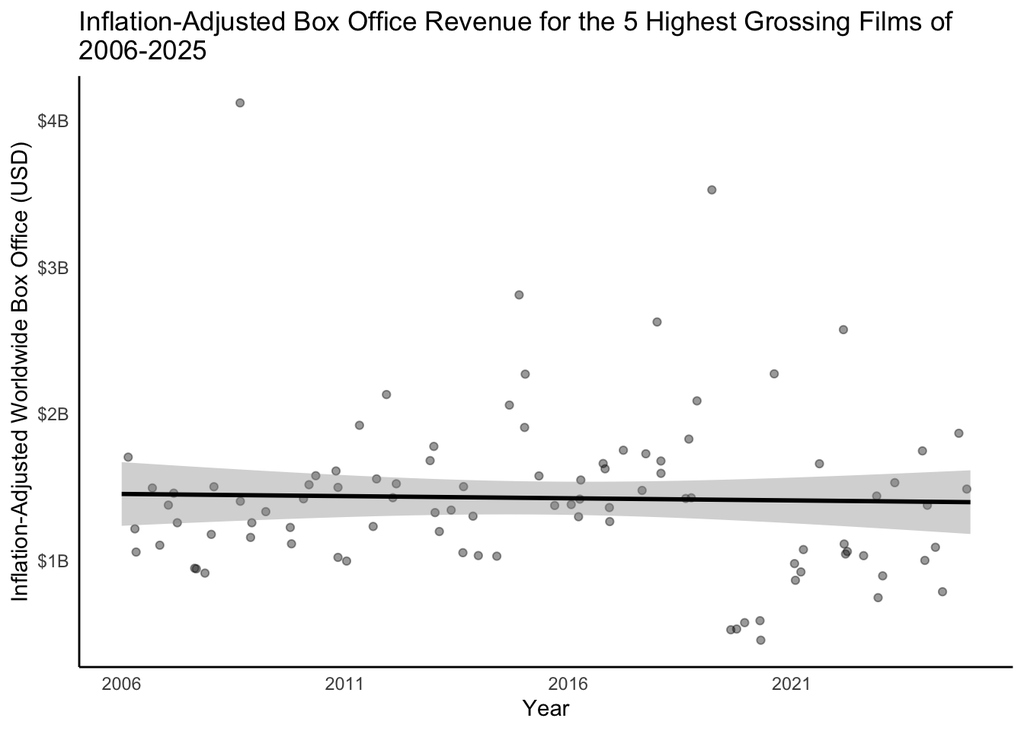

```r
Graph_1_Scientific
```

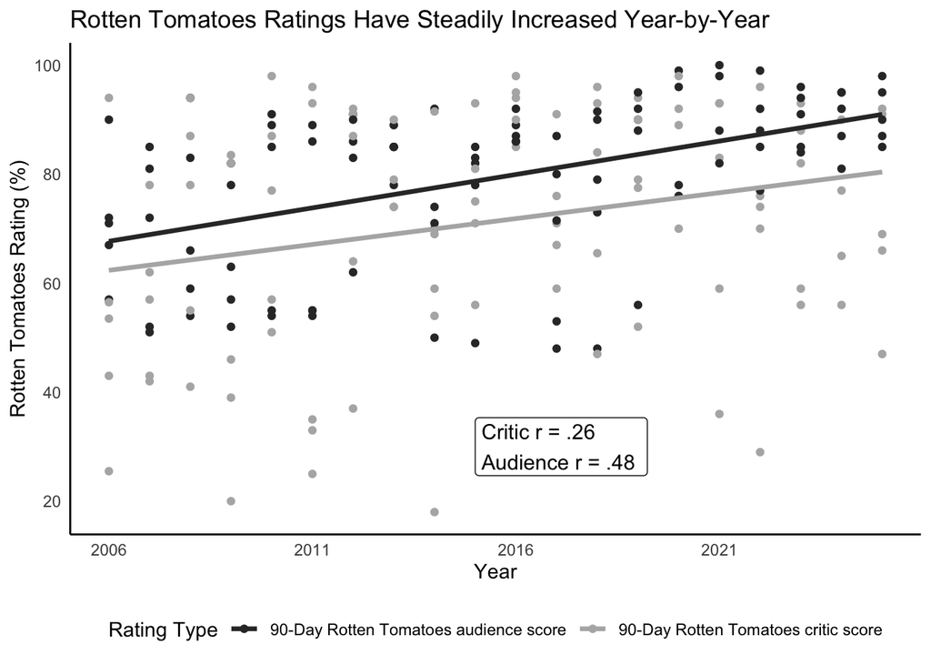

```r
Graph_1_Scientific_Rating
```

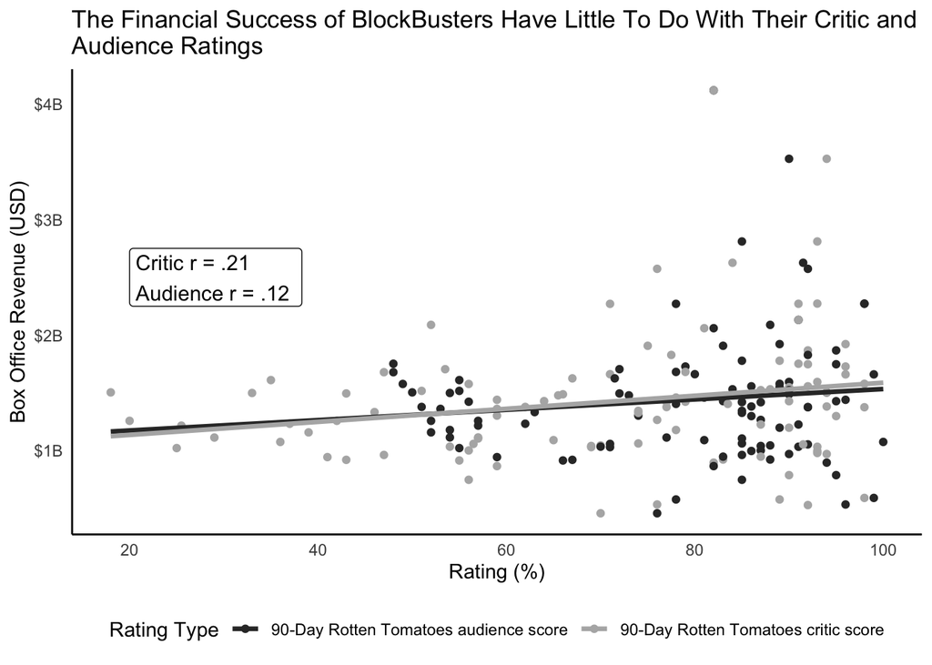

```r
Graph_2_Scientific
```

Although Sci-Fi movies achieved the highest average ratings and box office revenue, films that primarily fell under the genre of “Adventure” were simultaneously less likely to receive higher ratings from both critics and audiences (with larger discrepancies), yet no less successful at the box office. Ultimately, it’s clear that what defines a “successful” film has more to do with one’s definition of success (i.e., ratings, revenue, etc.) than any single characteristic of a film.

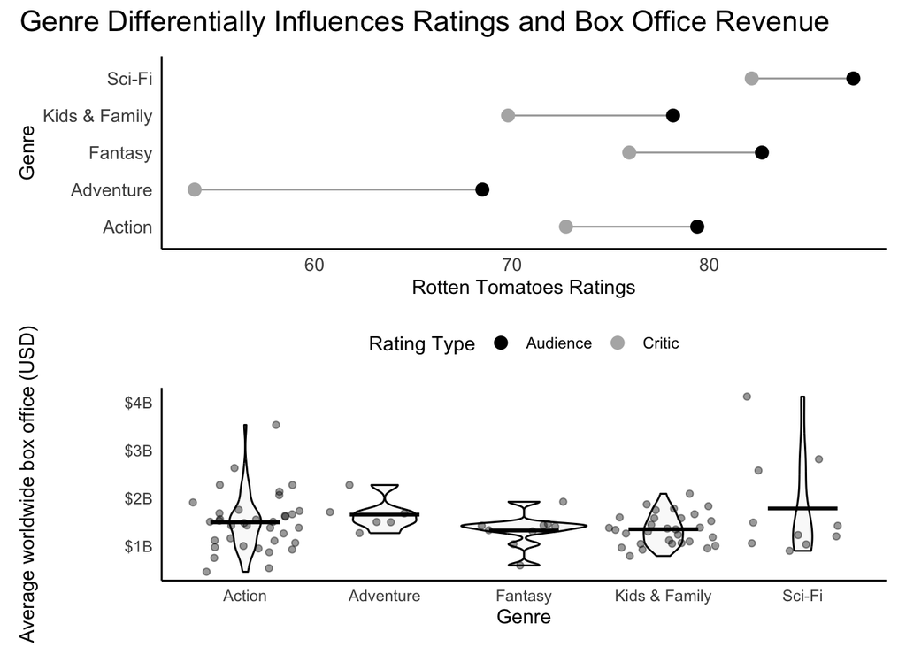

```r
Graph_3_Scientific_Ratings / Graph_3_Scientific_Box_Office +
  plot_annotation((title = str_wrap("Genre Differentially Influences Ratings and Box Office Revenue")),
  theme = theme(plot.title = element_text(size = 16, hjust = 0, colour = "black")))
```

Importantly, revenue figures do not consider the roles of budgets or profits, which may be better indicators of “success”. They also do not reflect the reality that some of these films would be distributed to a narrower selection of theatres or countries. Additionally, despite the fact that films based on well-known intellectual property (e.g., sequels) did not differ in their box office revenues or Rotten Tomatoes critic and audience ratings, only 13 of the 100 films in the current sample did not fall under this category. This may suggest that (1) the film industry disproportionately relies on established intellectual property because of greater perceived confidence in its resulting success and/or (2) the sample of 13 non-legacy films presented here are an atypically successful subset compared to movies based on established IP.

To best tease apart the factors contributing to various reflections of success, comparisons between the highest-earning movies of each year should also be made with the larger pool of films playing in theatres.

## Version B: Accessible/Dynamic

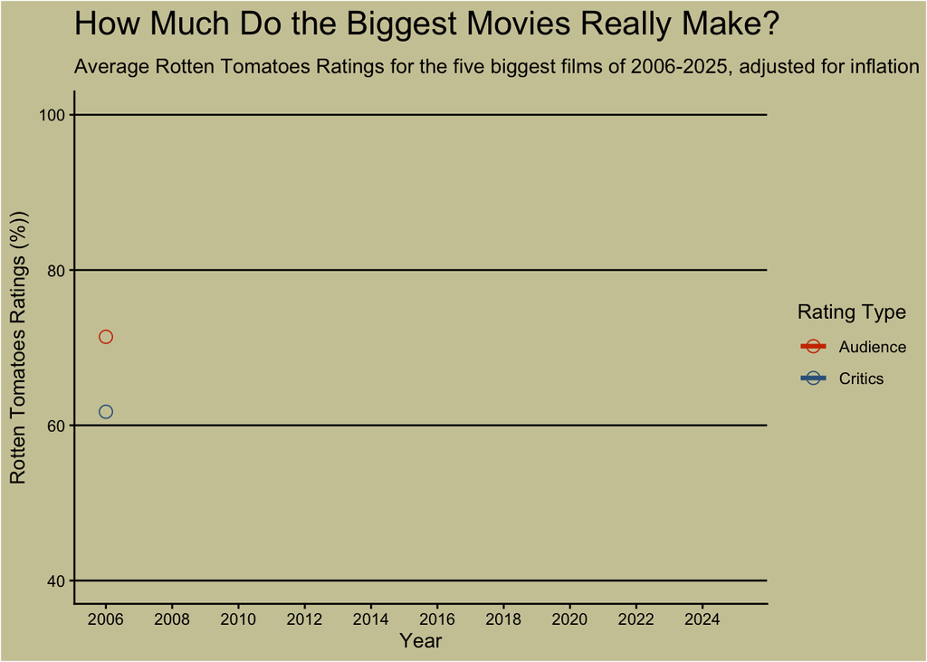

```r
animate(animated_plot, renderer = gifski_renderer())

animate(animated_plot, renderer = gifski_renderer())
```

Although both critic and audience ratings are related to box office revenue, these ratings aren’t very good at explaining box office turnout. Instead, we need to look at a factor that puts butts into seats in the first place: Genre

Interactive Audience Plot

```r
girafe(ggobj = Combined_Graph_2,
  width_svg = 12, height_svg = 12,
  options = list(opts_hover(css = "fill:black;stroke:black;cursor:pointer;"),
    opts_tooltip(css = "background-color:white;color:black;padding:5px;border-radius:3px;")))
```

[interactive chart not shown]

Although Sci-Fi movies achieved the highest average ratings and box office revenue, films that primarily fell under the genre of “Adventure” were simultaneously less likely to receive higher ratings from both critics and audiences (with larger discrepancies), yet no less successful at the box office. Ultimately, it’s clear that what defines a “successful” film has more to do with one’s definition of success (i.e., ratings, revenue, etc.) than any single characteristic of a film.

Importantly, revenue figures do not consider the roles of budgets or profits, which may be better indicators of “success”. They also do not reflect the reality that some of these films would be distributed to a narrower selection of theatres or countries. Additionally, despite the fact that films based on well-known intellectual property (e.g., sequels) did not differ in their box office revenues or Rotten Tomatoes critic and audience ratings, only 13 of the 100 films in the current sample did not fall under this category. This may suggest that (1) the film industry disproportionately relies on established intellectual property because of greater perceived confidence in its resulting success and/or (2) the sample of 13 non-legacy films presented here are an atypically successful subset compared to movies based on established IP.

To best tease apart the factors contributing to various reflections of success, comparisons between the highest-earning movies of each year should also be made with the larger pool of films playing in theatres.